# SC_01_POLI_ORG_EIN

Political organization EIN · Identifier report

## Overview

**Description**

Sec527 Pol Orgs - EIN

**Table**

`SC-P01-T01-POLITICAL-ORGS-INFO` (many)

**Location code**

`SCHED-C-PART-01-C-LINE-05-COL-C`

**Family**

`SCHED-C-PART-01-C-LINE-05-COL-C`

**Data type**

numeric (xsd: , EINType)

**Scope**

PZ

**Status**

unreviewed

3

xpaths mapped (2 observed)

22,868

filings with a value

2009–2024

tax years observed

3

open flags (0 errors)

## Flags

| Severity | Flag | Xpath | Detail |
| --- | --- | --- | --- |
| ⓘ info | `MANY_NOT_REPEATING` | IRS990ScheduleC/Section527PoliticalOrgGrp/EIN | many-to-one table, but 76% of values sit in no repeating element |
| ⓘ info | `MANY_NOT_REPEATING` | IRS990ScheduleC/Sec527PolOrgs/EIN | many-to-one table, but 75% of values sit in no repeating element |
| ⓘ info | `UNOBSERVED` | IRS990ScheduleC/Form990ScheduleCPartI/Sec527PolOrgs/EIN | never observed in TY2009-2024 filings |

## Xpaths

All mapped xpaths (under /Return/ReturnData or /Return/ReturnHeader), oldest first. Charts label each series by its xpath.

| Xpath | Form | First year | Last year | Versions | Filings | Repeats in |
| --- | --- | --- | --- | --- | --- | --- |
| IRS990ScheduleC/Sec527PolOrgs/EIN | Sched C | 2009 | 2012 | 15 | 2,480 | 22.8% |
| IRS990ScheduleC/Section527PoliticalOrgGrp/EIN | Sched C | 2013 | 2024 | 37 | 20,388 | 21.5% |
| IRS990ScheduleC/Form990ScheduleCPartI/Sec527PolOrgs/EIN | Sched C |  |  |  | 0 |  |

## Coverage

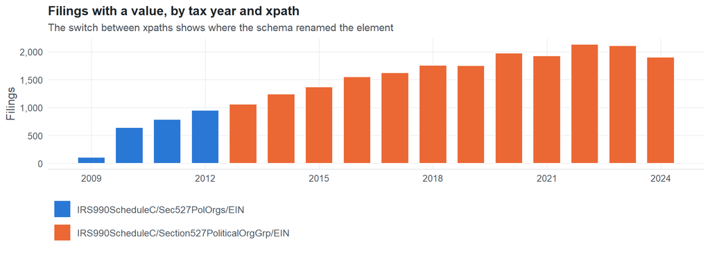

**Table view**

Table view: filings by tax year and series

| Tax year | IRS990ScheduleC/Sec527PolOrgs/EIN | IRS990ScheduleC/Section527PoliticalOrgGrp/EIN |
| --- | --- | --- |
| 2009 | 107 | 0 |
| 2010 | 639 | 0 |
| 2011 | 785 | 0 |
| 2012 | 949 | 0 |
| 2013 | 0 | 1,061 |
| 2014 | 0 | 1,243 |
| 2015 | 0 | 1,366 |
| 2016 | 0 | 1,551 |
| 2017 | 0 | 1,625 |
| 2018 | 0 | 1,754 |
| 2019 | 0 | 1,751 |
| 2020 | 0 | 1,972 |
| 2021 | 0 | 1,926 |
| 2022 | 0 | 2,130 |
| 2023 | 0 | 2,109 |
| 2024 | 0 | 1,900 |

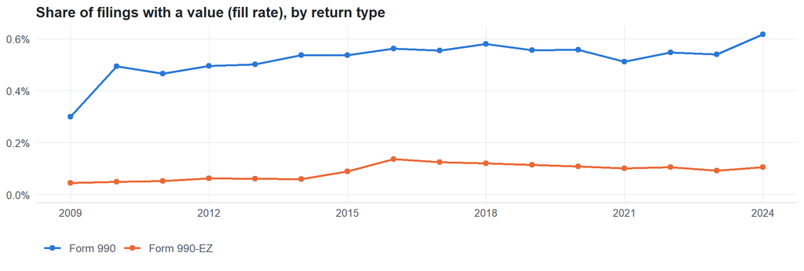

**Table view**

Table view: fill rate

| Tax year | Return type | Filings | All filings | Fill rate |
| --- | --- | --- | --- | --- |
| 2009 | Form 990 | 100 | 33,311 | 0.30% |
| 2009 | Form 990-EZ | 7 | 15,470 | 0.05% |
| 2010 | Form 990 | 608 | 123,025 | 0.49% |
| 2010 | Form 990-EZ | 31 | 63,326 | 0.05% |
| 2011 | Form 990 | 742 | 159,504 | 0.47% |
| 2011 | Form 990-EZ | 43 | 82,048 | 0.05% |
| 2012 | Form 990 | 890 | 179,688 | 0.50% |
| 2012 | Form 990-EZ | 59 | 93,750 | 0.06% |
| 2013 | Form 990 | 997 | 198,855 | 0.50% |
| 2013 | Form 990-EZ | 64 | 104,375 | 0.06% |
| 2014 | Form 990 | 1,174 | 218,619 | 0.54% |
| 2014 | Form 990-EZ | 69 | 116,417 | 0.06% |
| 2015 | Form 990 | 1,255 | 233,519 | 0.54% |
| 2015 | Form 990-EZ | 111 | 124,894 | 0.09% |
| 2016 | Form 990 | 1,372 | 243,903 | 0.56% |
| 2016 | Form 990-EZ | 179 | 130,484 | 0.14% |
| 2017 | Form 990 | 1,452 | 261,612 | 0.56% |
| 2017 | Form 990-EZ | 173 | 139,144 | 0.12% |
| 2018 | Form 990 | 1,574 | 271,442 | 0.58% |
| 2018 | Form 990-EZ | 180 | 149,384 | 0.12% |
| 2019 | Form 990 | 1,577 | 283,694 | 0.56% |
| 2019 | Form 990-EZ | 174 | 152,622 | 0.11% |
| 2020 | Form 990 | 1,788 | 320,342 | 0.56% |
| 2020 | Form 990-EZ | 184 | 169,864 | 0.11% |
| 2021 | Form 990 | 1,722 | 336,480 | 0.51% |
| 2021 | Form 990-EZ | 204 | 202,724 | 0.10% |
| 2022 | Form 990 | 1,913 | 349,055 | 0.55% |
| 2022 | Form 990-EZ | 217 | 206,130 | 0.11% |
| 2023 | Form 990 | 1,918 | 354,768 | 0.54% |
| 2023 | Form 990-EZ | 191 | 206,379 | 0.09% |
| 2024 | Form 990 | 1,712 | 277,298 | 0.62% |
| 2024 | Form 990-EZ | 188 | 178,867 | 0.11% |

## Repeating groups

Table cardinality in the concordance: **many**. 2 of 2 observed xpaths repeat within a filing.

Repeating element each xpath was observed in (from the raw indexed xpath)

| Xpath | Repeating element | Filings (summed over years) |
| --- | --- | --- |
| IRS990ScheduleC/Sec527PolOrgs/EIN | (none) | 1853 |
| IRS990ScheduleC/Sec527PolOrgs/EIN | IRS990ScheduleC/Sec527PolOrgs | 627 |
| IRS990ScheduleC/Section527PoliticalOrgGrp/EIN | (none) | 15413 |
| IRS990ScheduleC/Section527PoliticalOrgGrp/EIN | IRS990ScheduleC/Section527PoliticalOrgGrp | 4975 |

## Values

| Result | Check | Detail |
| --- | --- | --- |
| ✓ pass | Values have the EIN format | 100.0% of values match ^999999999$ |
| ⚠ fail | Stored as text | data type is numeric: leading zeros and letters would be lost |
| ▲ warn | No placeholder values | 1 filings use a placeholder such as 000000000 |
| ⓘ info | Leading zeros present | at least 1% of values start with 0 in some year, so numeric storage would change them |

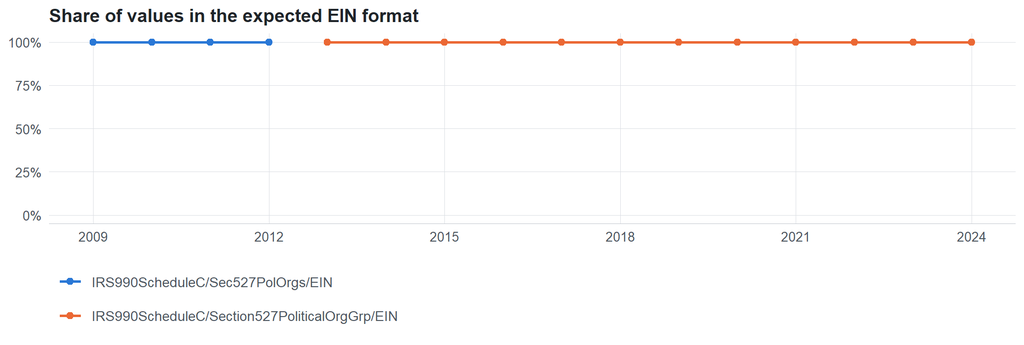

Value shapes (9 = digit, A = letter)

| Series | Shape | Expected | Filings |
| --- | --- | --- | --- |
| IRS990ScheduleC/Sec527PolOrgs/EIN | 999999999 | yes | 2,480 |
| IRS990ScheduleC/Section527PoliticalOrgGrp/EIN | 999999999 | yes | 20,388 |

## Examples

| Tax year | Return | Xpath | Organization | Value | Source |
| --- | --- | --- | --- | --- | --- |
| 2024 | 990 | IRS990ScheduleC/Section527PoliticalOrgGrp/EIN | NAIOP Central Florida Chapter Inc | 311794841 | [XML](https://gt990datalake-rawdata.s3.amazonaws.com/EfileData/XmlFiles/202503189349315390_public.xml) |
| 2023 | 990 | IRS990ScheduleC/Section527PoliticalOrgGrp/EIN | SURPLUS LINE ASSOCIATION OF OREGON | 710918580 | [XML](https://gt990datalake-rawdata.s3.amazonaws.com/EfileData/XmlFiles/202432859349300528_public.xml) |
| 2022 | 990 | IRS990ScheduleC/Section527PoliticalOrgGrp/EIN | Chicago Association of REALTORS | 370951209 | [XML](https://gt990datalake-rawdata.s3.amazonaws.com/EfileData/XmlFiles/202422289349302662_public.xml) |
| 2021 | 990 | IRS990ScheduleC/Section527PoliticalOrgGrp/EIN | BERKELEY FEDERATION OF TEACHERS | 883460302 | [XML](https://gt990datalake-rawdata.s3.amazonaws.com/EfileData/XmlFiles/202320679349300427_public.xml) |
| 2020 | 990 | IRS990ScheduleC/Section527PoliticalOrgGrp/EIN | LONG ISLAND BOARD OF REALTORS INC | 361520690 | [XML](https://gt990datalake-rawdata.s3.amazonaws.com/EfileData/XmlFiles/202133169349309243_public.xml) |
| 2019 | 990 | IRS990ScheduleC/Section527PoliticalOrgGrp/EIN | SEIU HEALTHCARE PENNSYLVANIA | 200859683 | [XML](https://gt990datalake-rawdata.s3.amazonaws.com/EfileData/XmlFiles/202043179349303969_public.xml) |
| 2018 | 990 | IRS990ScheduleC/Section527PoliticalOrgGrp/EIN | LABORERS INTERNATIONAL UNION OF NORTH | 364387037 | [XML](https://gt990datalake-rawdata.s3.amazonaws.com/EfileData/XmlFiles/201943379349300404_public.xml) |
| 2017 | 990 | IRS990ScheduleC/Section527PoliticalOrgGrp/EIN | AMERICAN WIND ENERGY ASSOCIATION | 471718814 | [XML](https://gt990datalake-rawdata.s3.amazonaws.com/EfileData/XmlFiles/201822999349300322_public.xml) |
| 2016 | 990 | IRS990ScheduleC/Section527PoliticalOrgGrp/EIN | Kansas Health Care Association Inc | 486180239 | [XML](https://gt990datalake-rawdata.s3.amazonaws.com/EfileData/XmlFiles/201741749349300609_public.xml) |
| 2015 | 990 | IRS990ScheduleC/Section527PoliticalOrgGrp/EIN | INTERNATIONAL ORGANIZATION OF MASTERS | 132903629 | [XML](https://gt990datalake-rawdata.s3.amazonaws.com/EfileData/XmlFiles/201632529349300813_public.xml) |
| 2014 | 990 | IRS990ScheduleC/Section527PoliticalOrgGrp/EIN | JONESBORO BOARD OF REALTORS INC | 710553498 | [XML](https://gt990datalake-rawdata.s3.amazonaws.com/EfileData/XmlFiles/201531699349300013_public.xml) |
| 2013 | 990 | IRS990ScheduleC/Section527PoliticalOrgGrp/EIN | OREGON HOME BUILDERS ASSOCIATION | 931198725 | [XML](https://gt990datalake-rawdata.s3.amazonaws.com/EfileData/XmlFiles/201443049349300334_public.xml) |

## Reviewer checklist

- The definition matches the form line and instructions for every xpath’s schema years.
- Every xpath pooled here measures the same thing on the 990 and 990-EZ (close enough for analysis).
- The coverage chart has no unexplained gaps or jumps between tax years.
- Each open flag is fixed, or accepted with a note in validation_log.csv.
- The data type is text so leading zeros and letters survive.
- The identifier belongs to the entity the variable names (the filer, preparer, related organization…).
- Formats with and without punctuation (e.g. ZIP+4, dashes) are normalized consistently downstream.

Record the review as a row in `inst/extdata/src/validation_log.csv` (variable_name, reviewer, date, status, note). Evidence built 2026-09-23 17:09:04 MST from the ef2 DuckDB builds (tax years 2009–2024).